# Low cost conservation: Fisheries gear threats to marine species

Tim Cashion, Travis Tai, Vicky Lam, Daniel Pauly, and U. Rashid Sumaila

Fri Sep 20 10:25:28 2019

Target Journals: Science, Nature, PNAS, Science Advances, Nature Sustainability, Conservation Biology

Potential collaborators: Casey O’Hara; Ben Halpern

Sentence summary: Fishing gear specific threats to marine species demonstrates lower-cost trade-offs between fisheries and conservation goals.

## 0.1 Abstract

Keywords: fishing method, IUCN, fishing pressure, conservation

## 0.2 Introduction

Fishing is a major threat to many marine species globally (*1*). However, different fishing gears are heterogeneous in their spatial extent and their impacts on different species. Therefore, treating different fisheries homogenously with regard to their spatial management likely causes unneeded conflict between fisheries and conservation priorities, and may impose too high costs without necessarily achieving their intended conservation benefits. Here, we aim to clarify this through a greater examination of fisheries threats related to specific fishing gears and their spatial overlap with species of conservation concern. Recent studies have highlighted the spatial extent of fisheries (*2*, *3*), as well as the fisheries risk to species of conservation concern (*4*). While fisheries pose obvious conservation concerns for both targeted and incidentally captured species (*5*), they also provide livelihoods and food security to millions and billions, respectively (*6*). Therefore, the goals of fisheries and conservation must be balanced to minimize the costs and maximize the benefits where possible.

Previous analyses have demonstrated these trade-offs between fisheries and ecosystem health (*7*). Although win-win scenarios are desirable, they are often only possible in overly simplified models that do not account for all variables such as employment for fishers (*7*) or spillover impacts to other areas of importance (*8*). It is therefore important to consider the different scales at which these conservation plans act and the implicit trade-offs between social and ecological outcomes in many plans (*8*). In addition, greater consideration of heterogeneity of fisheries can lead to more positive fishery outcomes without compromising conservation goals (*9*).

## 0.3 Results

### 0.3.1 Fishing threats to IUCN species

For the 14,126 marine species included on the IUCN Red List, fishing is identified by the IUCN as a threat to 4,455 of them (31.5%) (Threat category 5.4: fishing and harvesting aquatic resources). This threat is from both large- and small-scale sectors, and from intentional and unintentional capture (Figure 1A). According to the identified threats, the small-scale sector is a threat to a greater number of species than the intentional or unintentional capture by the large-scale sector. Interestingly, most of these impacts are identified to be of low or of an unknown impact with very few species having fishing identified as a medium or high impact threat on their population.

Within marine Red List species, over 2,500 have ‘trawls’ listed as a gear that catches them (Figure 1B). While many of these species have an elevated risk of extinction (Near Threatened and higher) most are either Least Concern or Data Deficient within these gear types. The top results are generally more vague gear terms and could be attributable to several types of fishing gear (e.g., trawl nets, gillnets, seine nets all fall under ‘nets’). The more specific gear categories identified are used in the remaining parts of the analysis (Table S2).

From the gear types we have previously identified (Figure 1C) we see again that bottom trawl fisheries are associated with the largest number of Red List species. However, we see these species are mainly in the Data Deficient, Least Concern, and Near Threatened categories while gillnet gears have the most number of species in the Threatened categories (Vulnerable, Endangered, and Critically Endangered).

[figure not shown]

Figure 1: IUCN fishing gear threats: species categorized by fishing gear threat (A); fishing gear threats by gear types listed (B); and identified gear types by threat status (C). Note: DD: Data Deficient; LC: Least Concern; NT: Near Threatened; VU: Vulnerable; EN: Endangered; CR: Critically Endangered.

### 0.3.2 Low-cost solutions to gear threats and easy conservation wins

Globally, bottom trawl fisheries average fisheries profits are $48 per km<sup>2</sup> of area fished (Table 1). However, they occur in cells with an average of 11 species at risk to this gear, with an average biodiversity risk score of Near Threatened (0.19). However, their generally high value catches make them perform relatively well overall. In contrast, longline fisheries have low profits per area occupied ($8) as they fish over a large spatial area. While they operate in areas with a similar biodiversity risk score as bottom trawl fisheries (0.19), they do so with much lower returns meaning they produce less fisheries profits for their relative conservations risk (weighted threat score) than bottom trawl fisheries.

Table 1: Mean values of measures of fisheries conservation concern and profit by gear type at a 0.5° by 0.5° scale.

| Gear type | Profit ($/km<sup>2</sup>) | Number of species | Weighted Threat Score | Biodiversity Risk Score |
| --- | --- | --- | --- | --- |
| Bottom trawl | 48.09 | 10.9 | 1.98 | 0.19 |
| Gillnet | 22.55 | 35.4 | 5.95 | 0.16 |
| Longline | 8.11 | 25.5 | 5.01 | 0.19 |
| Pelagic trawl | -133.66 | 1.8 | 0.20 | 0.06 |
| Purse seine | 8.14 | 22.0 | 3.90 | 0.16 |
| Small scale | 530.67 | 23.0 | 2.81 | 0.13 |

If we consider each spatial cell an independently managed grid, we can examine the trade-offs required in each based on their fisheries profits and conservation value (Figure 2). We find that although bottom trawl fisheries operate in many spatial cells of conservation concern (high ‘weighted threat score’ values), they are also generating substantial profits from these fisheries. Gillnets, alternatively, have a large number of cells that are below the median value for fisheries profits and have high weighted threat scores. Pelagic trawls have low weighted threat scores overall and thus the reduction in their use may not lead to large conservation gains.

Here, we present six major gear types that together account for 92% of global fisheries catches (landings and discards) (*13*). Bottom trawls, gillnets, and longlines have many more cells where the weighted threat score is higher than the median, especially in contrast to pelagic trawls, purse seines and small-scale gears. Among these higher impact gears, there is a diversity in the value of the fisheries profit achieved in each grid cell. Interestingly, gillnet fisheries are operating in many areas of high conservation concern with fisheries profits below the median value (across gear types). This demonstrates that the social costs of this gear are higher than previously thought, and may not be net positive given their relatively poor private profits achieved (mainly below the median). In comparison, bottom trawl fisheries while overlapping on the weighted threat score dimension with gillnet fisheries, achieve higher profits thus representing a conflict between conservation goals and fisheries goals. Small-scale gears and purse seine have mixed results with weighted threat scores not nearly as high as gillnet or bottom trawls, and a mix of high and low profit areas. Pelagic trawls are often used solely for relatively low-value species (from krill to Alaska pollock), but have very low weighted threat scores throughout their range of fisheries profits.

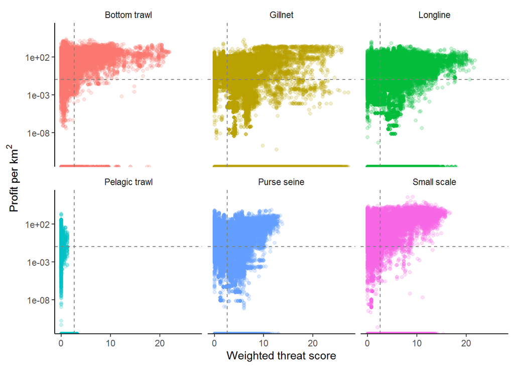

Figure 2: Fisheries profits (log scaled) and weighted score by cell (0.5° by 0.5° grid) for major gear types. Grey dashed lines indicate the median values (excluding values of 0) across gear types for fisheries profits per km<sup>2</sup> and weighted threat score.

### 0.3.3 Protecting the high seas

Areas beyond national jurisdiction (i.e., the high seas) have recently received increased attention for their protection for biodiversity and fishery gains (*14*, *15*), while leading to little losses in terms of food security (*16*). According to our framework, the high seas have cells in all four quadrants of our conceptual figure, but there is a large bias towards “areas of low concern” and “easy wins” (Figure 3). This confirms earlier analysis of the lack of importance of high seas fisheries, and although the high seas is dominated by areas of low concern, it has vast amounts that fall into ‘easy wins’ with very few cells in fishery prioritization or fishery competition. Therefore, the question may be changed from which parts of the high seas should we protect, to which parts of the high seas should remain as fishing areas (*17*) if any?

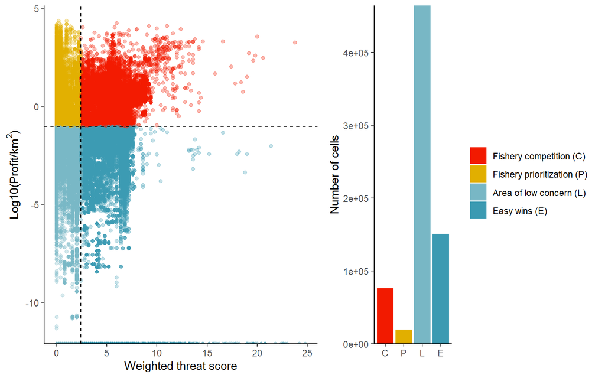

## 0.4 Discussion

Previous research has focused on potential trade-offs between fisheries and conservation and where we can search for win-win situations in these two aims. While it has been shown that often there are benefits to reducing fisheries capacity and fishing to both fisheries (*18*) and conservation (*19*), these benefits are not shared evenly. Reductions in fishing capacity often mean reductions in employment (*7*). In addition, closing areas to fisheries can often have similar effects forcing some fishers out with an often unequal distribution of benefits and costs between different sectors (including eco-tourism) and between different fisheries (*20*, *21*).

While O’Hara et al. (*12*) highlighted the areas for future conservation protection for marine protected areas (MPAs), we identify the areas that would also meet with major or lesser fisheries overlap and thus competition. In these areas, we assume the placement of MPAs would be more contentious due to the reliance on these natural resources. We also highlight areas with the lowest fisheries profits trade-offs for the most conservation protection where conservation should be prioritized.

This analysis highlights at a broad scale where fisheries or conservation can be prioritized, and where there are competing aims between these areas. Areas close to shore are areas of large fisheries importance, especially to small-scale fisheries, but coastal areas are also the most biodiverse regions of the marine realm. These areas are generally categorized as ‘competition’ areas. However, this analysis adds to existing MPA discussions that may lead to less contentious implementation of MPAs where certain fisheries can co-exist depending on the MPA goals (species conservation versus resource conservation) and current fisheries threats (as measured by the weighted threat score).

It is important to caveat our study knowing that we cannot fully account for the current extent of humanity’s use of the oceans and this study has focused on fisheries. Small-scale fisheries are critical to coastal livelihoods across the world and must not be compromised by overly broad conservation initiatives, but instead included when implementing actions to improve aspects of ocean health (e.g. (*24*)).

In addition, while we use catch and fisheries profits as a proxy for importance, these are not adjusted for their importance to the country (i.e., percentage of GDP from fisheries revenues or percentage of animal protein from locally caught fish), nor do they take into account differences in purchasing power parity where $1000 of fisheries profits is much more valuable in poorer countries than in industrialized countries.

## 0.5 Conclusion

Our results highlight areas of high conservation concern for particular fishing gears, and areas of high overlap with multiple fishing gear threats and multiple species of conservation concern. We also highlight areas with the potential for low-cost fishing closures leading to maximum protection of species negatively affected by these fishing gears. Interestingly, gillnet fisheries represent a greater opportunity than the often demonized bottom trawl fisheries according to our analysis due to the high fisheries profits derived from many bottom trawl catches. This analysis can help inform future conservation planning with areas of low-cost trade-offs in comparison to areas with much higher costs for equal conservation benefits.

## 0.6 Acknowledgements

TC acknowledges funding support of the Social Sciences and Humanities Research Council of Canada and the Four Year Fellowship from the University of British Columbia. DP Acknowledges support from the *Sea Around Us*, which is funded by a number of philanthropic foundations.

## References

1. J. B. C. Jackson, M. X. Kirby, W. H. Berger, K. a Bjorndal, L. W. Botsford, B. J. Bourque, R. H. Bradbury, R. Cooke, J. Erlandson, J. a Estes, T. P. Hughes, S. Kidwell, C. B. Lange, H. S. Lenihan, J. M. Pandolfi, C. H. Peterson, R. S. Steneck, M. J. Tegner, R. R. Warner, Historical overfishing and the recent collapse of coastal ecosystems. *Science (New York, N.Y.)*. **293**, 629–37 (2001).

2. D. A. Kroodsma, J. Mayorga, T. Hochberg, N. A. Miller, K. Boerder, F. Ferretti, A. Wilson, B. Bergman, T. D. White, B. A. Block, P. Woods, B. Sullivan, C. Costello, B. Worm, Tracking the global footprint of fisheries. *Science (New York, N.Y.)*. **359**, 904–908 (2018).

3. R. O. Amoroso, A. M. Parma, C. R. Pitcher, R. A. Mcconnaughey, S. Jennings, Comment on "Tracking the global footprint of fisheries". *Science*. **361**, eaat6713 (2018).

4. N. Queiroz, N. E. Humphries, A. Couto, M. Vedor, I. da Costa, A. M. M. Sequeira, G. Mucientes, A. M. Santos, F. J. Abascal, D. L. Abercrombie, K. Abrantes, D. Acuña-Marrero, A. S. Afonso, P. Afonso, D. Anders, G. Araujo, R. Arauz, P. Bach, A. Barnett, D. Bernal, M. L. Berumen, S. B. Lion, N. P. A. Bezerra, A. V. Blaison, B. A. Block, M. E. Bond, R. W. Bradford, C. D. Braun, E. J. Brooks, A. Brooks, J. Brown, B. D. Bruce, M. E. Byrne, S. E. Campana, A. B. Carlisle, D. D. Chapman, T. K. Chapple, J. Chisholm, C. R. Clarke, E. G. Clua, J. E. M. Cochran, E. C. Crochelet, L. Dagorn, R. Daly, D. D. Cortés, T. K. Doyle, M. Drew, C. A. J. Duffy, T. Erikson, E. Espinoza, L. C. Ferreira, F. Ferretti, J. D. Filmalter, G. C. Fischer, R. Fitzpatrick, J. Fontes, F. Forget, M. Fowler, M. P. Francis, A. J. Gallagher, E. Gennari, S. D. Goldsworthy, M. J. Gollock, J. R. Green, J. A. Gustafson, T. L. Guttridge, H. M. Guzman, N. Hammerschlag, L. Harman, F. H. V. Hazin, M. Heard, A. R. Hearn, J. C. Holdsworth, B. J. Holmes, L. A. Howey, M. Hoyos, R. E. Hueter, N. E. Hussey, C. Huveneers, D. T. Irion, D. M. P. Jacoby, O. J. D. Jewell, R. Johnson, L. K. B. Jordan, S. J. Jorgensen, W. Joyce, C. A. K. Daly, J. T. Ketchum, A. P. Klimley, A. A. Kock, P. Koen, F. Ladino, F. O. Lana, J. S. E. Lea, F. Llewellyn, W. S. Lyon, A. MacDonnell, B. C. L. Macena, H. Marshall, J. D. McAllister, R. McAuley, M. A. Meÿer, J. J. Morris, E. R. Nelson, Y. P. Papastamatiou, T. A. Patterson, C. Peñaherrera-Palma, J. G. Pepperell, S. J. Pierce, F. Poisson, L. M. Quintero, A. J. Richardson, P. J. Rogers, C. A. Rohner, D. R. L. Rowat, M. Samoilys, J. M. Semmens, M. Sheaves, G. Shillinger, M. Shivji, S. Singh, G. B. Skomal, M. J. Smale, L. B. Snyders, G. Soler, M. Soria, K. M. Stehfest, J. D. Stevens, S. R. Thorrold, M. T. Tolotti, A. Towner, P. Travassos, J. P. Tyminski, F. Vandeperre, J. J. Vaudo, Y. Y. Watanabe, S. B. Weber, B. M. Wetherbee, T. D. White, S. Williams, P. M. Zárate, R. Harcourt, G. C. Hays, M. G. Meekan, M. Thums, X. Irigoien, V. M. Eguiluz, C. M. Duarte, L. L. Sousa, S. J. Simpson, E. J. Southall, D. W. Sims, Global spatial risk assessment of sharks under the footprint of fisheries. *Nature*. **4** (2019), doi:10.1038/s41586-019-1444-4.

5. R. L. Lewison, L. B. Crowder, A. J. Read, S. A. Freeman, Understanding impacts of fisheries bycatch on marine megafauna. *Trends in Ecology & Evolution*. **19**, 598–604 (2004).

6. FAO, “The State of World Fisheries and Aquaculture 2018 - Meeting the sustainable development goals” (Rome, 2018), p. 210.

7. W. W. L. Cheung, U. R. Sumaila, Trade-offs between conservation and socio-economic objectives in managing a tropical marine ecosystem. *Ecological Economics*. **66**, 193–210 (2008).

8. T. O. McShane, P. D. Hirsch, T. C. Trung, A. N. Songorwa, A. Kinzig, B. Monteferri, D. Mutekanga, H. V. Thang, J. L. Dammert, M. Pulgar-Vidal, M. Welch-Devine, J. Peter Brosius, P. Coppolillo, S. O’Connor, Hard choices: Making trade-offs between biodiversity conservation and human well-being. *Biological Conservation*. **144**, 966–972 (2011).

9. C. J. Klein, C. Steinback, M. Watts, A. J. Scholz, H. P. Possingham, Spatial marine zoning for fisheries and conservation. *Frontiers in Ecology and the Environment*. **8**, 349–353 (2010).

10. IUCN, IUCN Red List of Threatened Species. Version 2019-1 (2019), (available at www.iucnredlist.org).

11. D. Pauly, D. Zeller, Eds., *Sea Around Us Concepts, Design and Data (seaaroundus.org)* (2015).

12. C. C. O’Hara, J. Carlos Villaseñor-Derbez, G. M. Ralph, B. S. Halpern, Mapping status and conservation of global at-risk marine biodiversity. *Conservation Letters* (2019), doi:10.1111/conl.12651.

13. T. Cashion, D. Al-abdulrazzak, D. Belhabib, B. Derrick, E. Divovich, D. K. Moutopoulos, S.-l. Noël, M. L. D. Palomares, L. C. L. Teh, D. Zeller, D. Pauly, Reconstructing global marine fishing gear use: Catches and landed values by gear type and sector. *Fisheries Research*. **206**, 57–64 (2018).

14. U. R. Sumaila, V. W. Y. Lam, D. D. Miller, L. Teh, R. A. Watson, D. Zeller, W. W. L. Cheung, I. M. Côté, A. D. Rogers, C. Roberts, E. Sala, D. Pauly, Winners and losers in a world where the high seas is closed to fishing. *Scientific Reports*. **5**, 8481 (2015).

15. C. White, C. Costello, Close the High Seas to Fishing? *PLoS Biology*. **12**, 1–5 (2014).

16. L. Schiller, M. Bailey, J. Jacquet, E. Sala, “High seas fisheries play a negligible role in addressing global food security” (2018), pp. 8351–8359.

17. C. Walters, in *Reinventing fisheries management*, T. J. Pitcher, D. Pauly, P. Hart, Eds. (Dordrecht, 1998), pp. 279–288.

18. U. R. Sumaila, W. W. L. Cheung, A. Dyck, K. Gueye, L. Huang, V. Lam, D. Pauly, T. Srinivasan, W. Swartz, R. Watson, D. Zeller, Benefits of rebuilding global marine fisheries outweigh costs. *PLoS ONE*. **7** (2012), doi:10.1371/journal.pone.0040542.

19. M. G. Burgess, G. R. McDermott, B. Owashi, L. E. Peavey Reeves, T. Clavelle, D. Ovando, B. P. Wallace, R. L. Lewison, S. D. Gaines, C. Costello, Protecting marine mammals, turtles, and birds by rebuilding global fisheries. *Science (New York, N.Y.)*. **359**, 1255–1258 (2018).

20. D. A. Gill, S. H. Cheng, L. Glew, E. Aigner, N. J. Bennett, M. B. Mascia, Social Synergies, Tradeoffs, and Equity in Marine Conservation Impacts. *Annual Review of Environment and Resources*. **44**, annurev–environ–110718–032344 (2019).

21. J. E. Cinner, T. Daw, C. Huchery, P. Thoya, A. Wamukota, M. Cedras, C. Abunge, Winners and Losers in Marine Conservation: Fishers’ Displacement and Livelihood Benefits from Marine Reserves. *Society and Natural Resources*. **27**, 994–1005 (2014).

22. Committee on Ecosystem Effects of Fishing, *Effects of Trawling and Dredging on Seafloor Habitat* (National Academy Press, Washington, DC, 2002; http://www.nap.edu/catalog/10323).

23. N. K. Dulvy, S. L. Fowler, J. A. Musick, R. D. Cavanagh, P. M. Kyne, L. R. Harrison, J. K. Carlson, L. N. Davidson, S. V. Fordham, M. P. Francis, C. M. Pollock, C. A. Simpfendorfer, G. H. Burgess, K. E. Carpenter, L. J. Compagno, D. A. Ebert, C. Gibson, M. R. Heupel, S. R. Livingstone, J. C. Sanciangco, J. D. Stevens, S. Valenti, W. T. White, Extinction risk and conservation of the world’s sharks and rays. *eLife*. **3** (2014), doi:10.7554/eLife.00590.

24. B. S. Halpern, C. Longo, D. Hardy, K. L. McLeod, J. F. Samhouri, S. K. Katona, K. Kleisner, S. E. Lester, J. Oleary, M. Ranelletti, A. A. Rosenberg, C. Scarborough, E. R. Selig, B. D. Best, D. R. Brumbaugh, F. S. Chapin, L. B. Crowder, K. L. Daly, S. C. Doney, C. Elfes, M. J. Fogarty, S. D. Gaines, K. I. Jacobsen, L. B. Karrer, H. M. Leslie, E. Neeley, D. Pauly, S. Polasky, B. Ris, K. St Martin, G. S. Stone, U. Rashid Sumaila, D. Zeller, An index to assess the health and benefits of the global ocean. *Nature*. **488**, 615–620 (2012).